# Mobile Price Project

Xiaotang Tang, Jiayin Sun, Congyuan Xu, Yuantai Huang

4/24/2021

1. Introduction:

*ID: The Ids.

*Battery_power: Total energy a battery can store in one time measured in mAh

*Blue: Has bluetooth or not

*Clock_speed: speed at which microprocessor executes instructions

*Dual_sim: Has dual sim support or not

*Fc: Front Camera megapixels

*Four_g: Has 4G or not

*Int_memory: Internal Memory in Gigabytes

*M_dep: Mobile Depth in cm

*Mobile_wt: Weight of mobile phone

*N_cores: Number of cores of processor

*Pc: Primary Camera megapixels

*Px_height: Pixel Resolution Height

*Px_width: Pixel Resolution Width

*Ram: Random Access Memory in Megabytes

*Sc_h: Screen Height of mobile in cm

*Sc_w: Screen Width of mobile in cm

*Three_g: Has 3G or not

*Touch_screen: Has touch screen or not

*Wifi: Has wifi or not

And our team wants to foucs on exploring these following questions:

1.Is there any effect on 3G by the factor of 4G? 2.Is there any effect on Wifi by the factor of Bluetooth? 3.Is there any relationship between Battery power and the number of cores? 4.What factors affect the selling price most?

To get a better understanding of those SMART questions above, we would like to apply hypothesis tests and simple linear regression models to to accomplish this task.

```r
library(ggplot2)
library(scales)
library(grid)
library(gridExtra)
library(dplyr)
setwd("/Users/sunemilyjiayin/Creative Cloud Files")
mobile.data <- read.csv("DS project_mobile.csv", header = TRUE)
print(mobile.data[is.na(mobile.data)])#Check if there are any null values in the dataset
```

```
## numeric(0)
```

```r
mobile.data$blue <- as.factor(mobile.data$blue)
mobile.data$dual_sim <- as.factor(mobile.data$dual_sim)
mobile.data$four_g <- as.factor(mobile.data$four_g)
mobile.data$n_cores <- as.factor(mobile.data$n_cores)
mobile.data$three_g <- as.factor(mobile.data$three_g)
mobile.data$touch_screen <- as.factor(mobile.data$touch_screen)
mobile.data$wifi <- as.factor(mobile.data$wifi)
mobile.data$price_range <- as.factor(mobile.data$price_range)
head(mobile.data)
```

```
##   battery_power blue clock_speed dual_sim fc four_g int_memory m_dep
## 1           842    0         2.2        0  1      0          7   0.6
## 2          1021    1         0.5        1  0      1         53   0.7
## 3           563    1         0.5        1  2      1         41   0.9
## 4           615    1         2.5        0  0      0         10   0.8
## 5          1821    1         1.2        0 13      1         44   0.6
## 6          1859    0         0.5        1  3      0         22   0.7
##   mobile_wt n_cores pc px_height px_width  ram sc_h sc_w talk_time three_g
## 1       188       2  2        20      756 2549    9    7        19       0
## 2       136       3  6       905     1988 2631   17    3         7       1
## 3       145       5  6      1263     1716 2603   11    2         9       1
## 4       131       6  9      1216     1786 2769   16    8        11       1
## 5       141       2 14      1208     1212 1411    8    2        15       1
## 6       164       1  7      1004     1654 1067   17    1        10       1
##   touch_screen wifi price_range
## 1            0    1           1
## 2            1    0           2
## 3            1    0           2
## 4            0    0           2
## 5            1    0           1
## 6            0    0           1
```

```r
str(mobile.data)
```

```
## 'data.frame':    2000 obs. of  21 variables:
##  $ battery_power: int  842 1021 563 615 1821 1859 1821 1954 1445 509 ...
##  $ blue         : Factor w/ 2 levels "0","1": 1 2 2 2 2 1 1 1 2 2 ...
##  $ clock_speed  : num  2.2 0.5 0.5 2.5 1.2 0.5 1.7 0.5 0.5 0.6 ...
##  $ dual_sim     : Factor w/ 2 levels "0","1": 1 2 2 1 1 2 1 2 1 2 ...
##  $ fc           : int  1 0 2 0 13 3 4 0 0 2 ...
##  $ four_g       : Factor w/ 2 levels "0","1": 1 2 2 1 2 1 2 1 1 2 ...
##  $ int_memory   : int  7 53 41 10 44 22 10 24 53 9 ...
##  $ m_dep        : num  0.6 0.7 0.9 0.8 0.6 0.7 0.8 0.8 0.7 0.1 ...
##  $ mobile_wt    : int  188 136 145 131 141 164 139 187 174 93 ...
##  $ n_cores      : Factor w/ 8 levels "1","2","3","4",..: 2 3 5 6 2 1 8 4 7 5 ...
##  $ pc           : int  2 6 6 9 14 7 10 0 14 15 ...
##  $ px_height    : int  20 905 1263 1216 1208 1004 381 512 386 1137 ...
##  $ px_width     : int  756 1988 1716 1786 1212 1654 1018 1149 836 1224 ...
##  $ ram          : int  2549 2631 2603 2769 1411 1067 3220 700 1099 513 ...
##  $ sc_h         : int  9 17 11 16 8 17 13 16 17 19 ...
##  $ sc_w         : int  7 3 2 8 2 1 8 3 1 10 ...
##  $ talk_time    : int  19 7 9 11 15 10 18 5 20 12 ...
##  $ three_g      : Factor w/ 2 levels "0","1": 1 2 2 2 2 2 2 2 2 2 ...
##  $ touch_screen : Factor w/ 2 levels "0","1": 1 2 2 1 2 1 1 2 1 1 ...
##  $ wifi         : Factor w/ 2 levels "0","1": 2 1 1 1 1 1 2 2 1 1 ...
##  $ price_range  : Factor w/ 4 levels "0","1","2","3": 2 3 3 3 2 2 4 1 1 1 ...
```

2. EDA(Exploratory Data Analysis)

Before getting into the deep analysis about this dataset, we first cleaned the dataset by turning 8 variables to factors. We want to use boxplots to make exploritory data analysis (EDA).

Is there any relationship between Battery power and the number of cores?

```r
mobile.data
```

[output not shown]

[output cut: 5988 more lines]

```r
cor(mobile.data$battery_power,as.numeric(mobile.data$n_cores,method = c("pearson")))
```

```
## [1] -0.02972726
```

```r
cor(mobile.data$battery_power,as.numeric(mobile.data$n_cores,method = c("kendall")))
```

```
## [1] -0.02972726
```

```r
cor(mobile.data$battery_power,as.numeric(mobile.data$n_cores,method = c("spearman")))
```

```
## [1] -0.02972726
```

```r
cor.test(mobile.data$battery_power,as.numeric(mobile.data$n_cores,method = c("spearman")))
```

```
##
##  Pearson's product-moment correlation
##
## data:  mobile.data$battery_power and as.numeric(mobile.data$n_cores, method = c("spearman"))
## t = -1.3294, df = 1998, p-value = 0.1839
## alternative hypothesis: true correlation is not equal to 0
## 95 percent confidence interval:
##  -0.07346247  0.01412207
## sample estimates:
##         cor
## -0.02972726
```

```r
cor.test(mobile.data$battery_power,as.numeric(mobile.data$n_cores,method = c("pearson")))
```

```
##
##  Pearson's product-moment correlation
##
## data:  mobile.data$battery_power and as.numeric(mobile.data$n_cores, method = c("pearson"))
## t = -1.3294, df = 1998, p-value = 0.1839
## alternative hypothesis: true correlation is not equal to 0
## 95 percent confidence interval:
##  -0.07346247  0.01412207
## sample estimates:
##         cor
## -0.02972726
```

```r
cor.test(mobile.data$battery_power,as.numeric(mobile.data$n_cores,method = c("kendall")))
```

```
##
##  Pearson's product-moment correlation
##
## data:  mobile.data$battery_power and as.numeric(mobile.data$n_cores, method = c("kendall"))
## t = -1.3294, df = 1998, p-value = 0.1839
## alternative hypothesis: true correlation is not equal to 0
## 95 percent confidence interval:
##  -0.07346247  0.01412207
## sample estimates:
##         cor
## -0.02972726
```

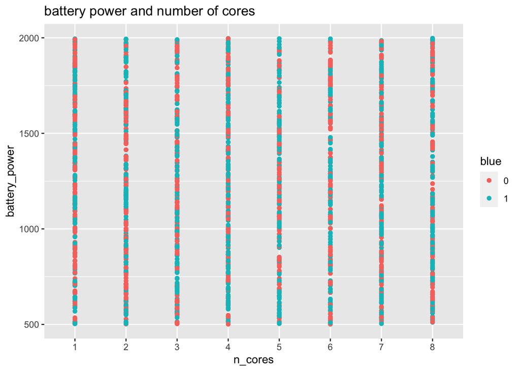

```r
#basic analysis
#plot of the battery power of number of cores
plot1<-ggplot(data = mobile.data, mapping = aes(x = n_cores,y = battery_power)) +
geom_point(aes(color=blue))+
  ggtitle("battery power and number of cores")
plot1
```

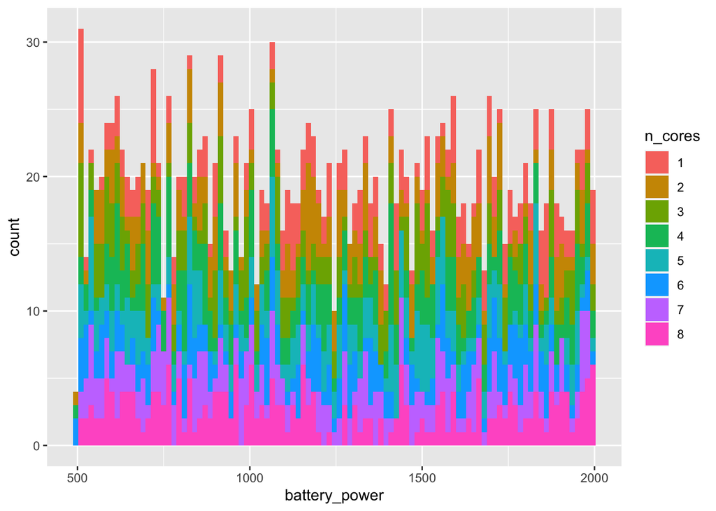

```r
#histogram battery power vs. number of cores
plot2<-ggplot(data = mobile.data)+
geom_histogram(aes(x=battery_power,fill=n_cores),binwidth = 15)
plot2
```

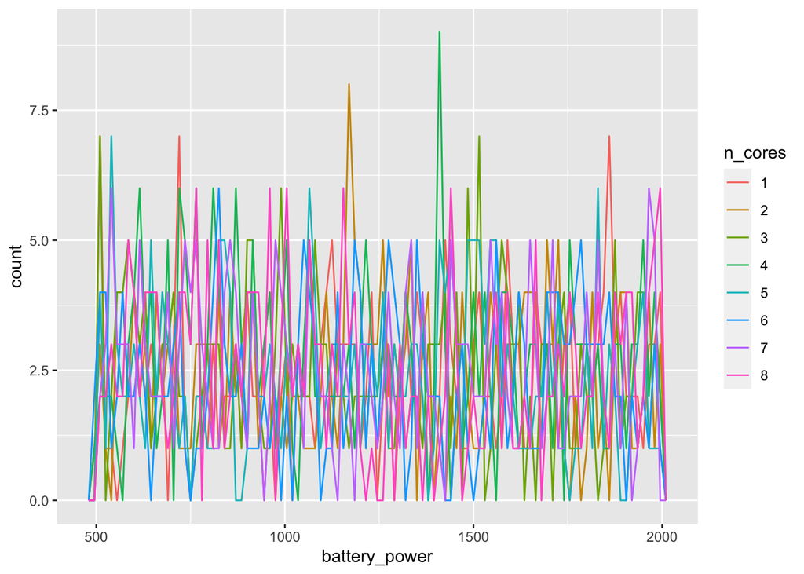

```r
plot3<-ggplot(data = mobile.data)+
geom_freqpoly(aes(x=battery_power,col=n_cores),binwidth=15)
plot3
```

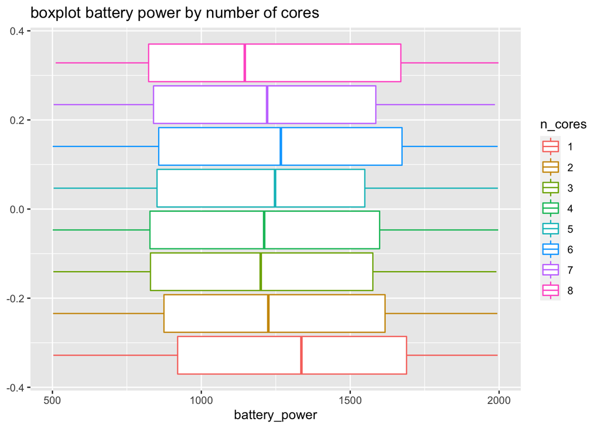

```r
#boxplot battery power by number of cores
plot4<-ggplot(data =mobile.data, mapping = aes(battery_power)) +
geom_boxplot(aes(col=n_cores))+
  ggtitle("boxplot battery power by number of cores")
plot4
```

```r
lm1<-lm(battery_power~n_cores,data=mobile.data)
summary(lm1)
```

```
##
## Call:
## lm(formula = battery_power ~ n_cores, data = mobile.data)
##
## Residuals:
##     Min      1Q  Median      3Q     Max
## -799.16 -388.23   -8.63  374.14  775.92
##
## Coefficients:
##             Estimate Std. Error t value Pr(>|t|)
## (Intercept)  1302.16      28.25  46.100   <2e-16 ***
## n_cores2      -62.88      39.74  -1.582   0.1138
## n_cores3      -87.08      39.78  -2.189   0.0287 *
## n_cores4      -76.97      38.76  -1.986   0.0472 *
## n_cores5      -76.16      39.78  -1.914   0.0557 .
## n_cores6      -46.94      40.46  -1.160   0.2461
## n_cores7      -79.81      39.29  -2.031   0.0423 *
## n_cores8      -74.35      39.40  -1.887   0.0593 .
## ---
## Signif. codes:  0 '***' 0.001 '**' 0.01 '*' 0.05 '.' 0.1 ' ' 1
##
## Residual standard error: 439.4 on 1992 degrees of freedom
## Multiple R-squared:  0.003533,   Adjusted R-squared:  3.163e-05
## F-statistic: 1.009 on 7 and 1992 DF,  p-value: 0.4227
```

```r
lm2<-glm(battery_power~n_cores,data=mobile.data)
summary(lm2)
```

```
##
## Call:
## glm(formula = battery_power ~ n_cores, data = mobile.data)
##
## Deviance Residuals:
##     Min       1Q   Median       3Q      Max
## -799.16  -388.23    -8.63   374.14   775.92
##
## Coefficients:
##             Estimate Std. Error t value Pr(>|t|)
## (Intercept)  1302.16      28.25  46.100   <2e-16 ***
## n_cores2      -62.88      39.74  -1.582   0.1138
## n_cores3      -87.08      39.78  -2.189   0.0287 *
## n_cores4      -76.97      38.76  -1.986   0.0472 *
## n_cores5      -76.16      39.78  -1.914   0.0557 .
## n_cores6      -46.94      40.46  -1.160   0.2461
## n_cores7      -79.81      39.29  -2.031   0.0423 *
## n_cores8      -74.35      39.40  -1.887   0.0593 .
## ---
## Signif. codes:  0 '***' 0.001 '**' 0.01 '*' 0.05 '.' 0.1 ' ' 1
##
## (Dispersion parameter for gaussian family taken to be 193082.3)
##
##     Null deviance: 385983631  on 1999  degrees of freedom
## Residual deviance: 384619848  on 1992  degrees of freedom
## AIC: 30027
##
## Number of Fisher Scoring iterations: 2
```

```r
aov1<-aov(battery_power~n_cores,data=mobile.data)
summary(aov1)
```

```
##               Df    Sum Sq Mean Sq F value Pr(>F)
## n_cores        7   1363783  194826   1.009  0.423
## Residuals   1992 384619848  193082
```

```r
battery_core.table=xtabs(~battery_power+n_cores,data=mobile.data)
battery_core.table
```

[output not shown]

[output cut: 1081 more lines]

```r
chisq.test(battery_core.table)
```

```
##
##  Pearson's Chi-squared test
##
## data:  battery_core.table
## X-squared = 7679.3, df = 7651, p-value = 0.4074
```